# Plotting and Color in R

Andrew Witherspoon

9/30/2018

```r
pal <- colorRamp(c("red", "blue"))
```

pal(0) will be full red:

```r
pal(0)
```

```
##      [,1] [,2] [,3]
## [1,]  255    0    0
```

pal(1) will be full blue:

```r
pal(1)
```

```
##      [,1] [,2] [,3]
## [1,]    0    0  255
```

pal(.5) will be a blend of red and blue (purple):

```r
pal(.5)
```

```
##       [,1] [,2]  [,3]
## [1,] 127.5    0 127.5
```

If you give this pal() a sequence of numbers between 0 and 1, it will return a sequence of colors between red and blue:

```r
pal(seq(0, 1, len = 10))
```

```
##            [,1] [,2]      [,3]
##  [1,] 255.00000    0   0.00000
##  [2,] 226.66667    0  28.33333
##  [3,] 198.33333    0  56.66667
##  [4,] 170.00000    0  85.00000
##  [5,] 141.66667    0 113.33333
##  [6,] 113.33333    0 141.66667
##  [7,]  85.00000    0 170.00000
##  [8,]  56.66667    0 198.33333
##  [9,]  28.33333    0 226.66667
## [10,]   0.00000    0 255.00000
```

Another option is using the colorRampPalette(), which will make your pal() function output hex color codes:

```r
pal <- colorRampPalette(c("red", "yellow"))
```

If you do pal(2), it will output a vector of two colors, full red and full yellow:

```r
pal(2)
```

```
## [1] "#FF0000" "#FFFF00"
```

If you do pal(10), it will output a vector of 10 colors - the first is full red, the last is full yellow. Then 8 in-between colors:

```r
pal(10)
```

```
##  [1] "#FF0000" "#FF1C00" "#FF3800" "#FF5500" "#FF7100" "#FF8D00" "#FFAA00"
##  [8] "#FFC600" "#FFE200" "#FFFF00"
```

The RColorBrewer package has pre-made pallettes. To get three colors from a RColorBrewer pallet, do this:

```r
library(RColorBrewer)
cols <- brewer.pal(3, "BuGn")
cols
```

```
## [1] "#E5F5F9" "#99D8C9" "#2CA25F"
```

Now we can use colorRampPalette() on our 3 colors (stored in cols) to create a smooth color ramp. We’ll use it on our volcano height matrix:

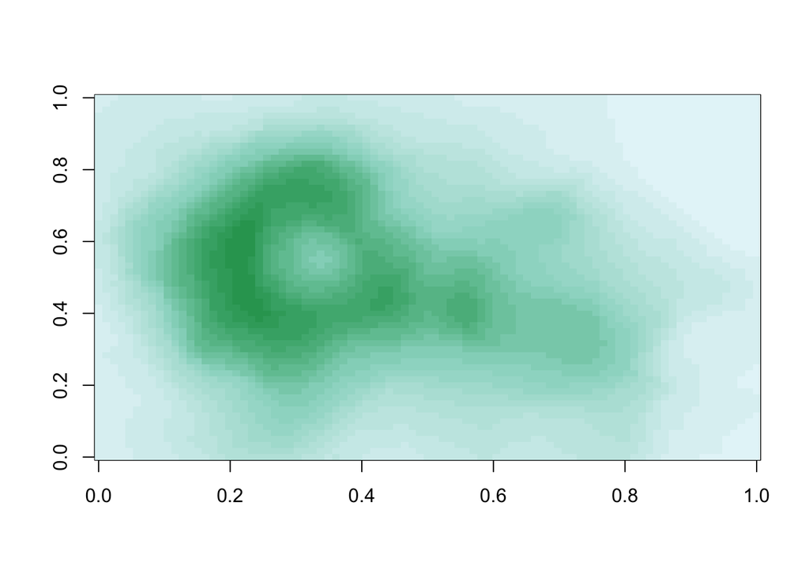

```r
pal <- colorRampPalette(cols)
image(volcano, col = pal(20))
```

The smoothScatter() function is usefull when you have a scatterplot with a lot of overlapping information, so that it is more readable. It essentially uses a histogram to make colors darker where there are lots of points:

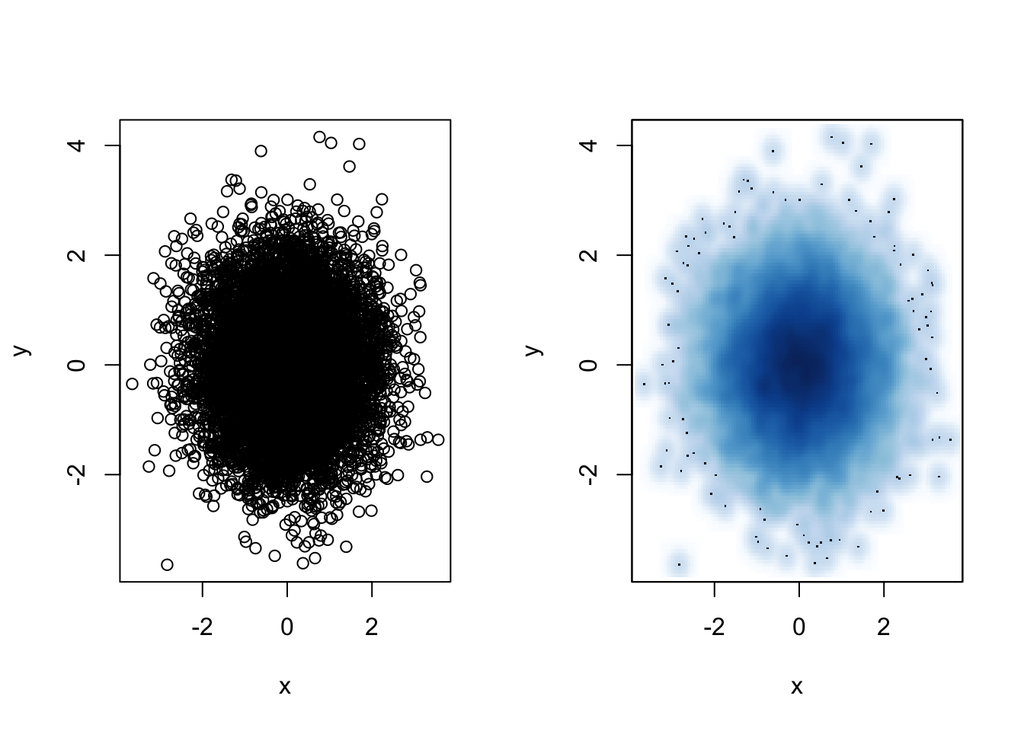

```r
par(mfrow = c(1,2))
x <- rnorm(10000)
y <- rnorm(10000)
plot(x,y)
smoothScatter(x,y)
```

```r
par(mfrow = c())
```

```
## named list()
```

The other option, of course, is to use transparency:

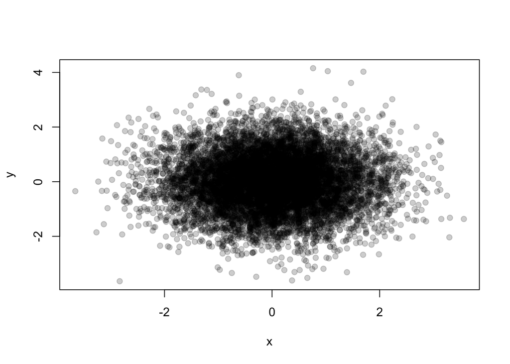

```r
plot(x,y, col = rgb(0,0,0,0.2), pch = 19) #0.2 is the alpha
```